# Data Science Job Posting Analysis

The demand for data scientists has surged in recent years, as companies increasingly rely on data-driven insights to make informed decisions. This analysis dives into a dataset from Kaggle, sourced from Glassdoor job postings, to explore the current landscape of data science roles and the factors that influence job opportunities and compensation.

In this notebook, we will examine data science job postings across various companies, industries, and regions. The dataset includes information such as job titles, salary estimates, company ratings, locations, industries, and company size. Our goal is to answer key questions like:

1. What are the average salary estimates for data science roles, and how do they differ by location and company size?
2. Which industries are offering the highest-paying data science roles?
3. How do company ratings correlate with salary estimates.
4. What skills or keywords appear most frequently in job descriptions?
5. Which regions and cities have the highest demand for data scientists?
6. How do salaries vary across different industries and company ownership types?
7. What are the top industries or sectors hiring for data science roles?
8. Which locations have the most data science job openings?
9. What is the relationship between a company’s founding year and rating?
10. What are the most common types of ownership among companies posting jobs?

The analysis begins by loading the dataset and exploring its structure to gain a preliminary understanding of the variables and their distributions.

## Importing Libraries and Dataset

```python
import pandas as pd
import numpy as np
import matplotlib.pyplot as plt
import seaborn as sns
from wordcloud import WordCloud
```

```python
df = pd.read_csv('Uncleaned_DS_jobs.csv')
```

```python
df.columns
```

```
Index(['index', 'Job Title', 'Salary Estimate', 'Job Description', 'Rating',
       'Company Name', 'Location', 'Headquarters', 'Size', 'Founded',
       'Type of ownership', 'Industry', 'Sector', 'Revenue', 'Competitors'],
      dtype='object')
```

```python
df.head()
```

|  | index | Job Title | Salary Estimate | Job Description | Rating | Company Name | Location | Headquarters | Size | Founded | Type of ownership | Industry | Sector | Revenue | Competitors |
| --- | --- | --- | --- | --- | --- | --- | --- | --- | --- | --- | --- | --- | --- | --- | --- |
| 0 | 0 | Sr Data Scientist | $137K-$171K (Glassdoor est.) | Description\n\nThe Senior Data Scientist is re... | 3.1 | Healthfirst\n3.1 | New York, NY | New York, NY | 1001 to 5000 employees | 1993 | Nonprofit Organization | Insurance Carriers | Insurance | Unknown / Non-Applicable | EmblemHealth, UnitedHealth Group, Aetna |
| 1 | 1 | Data Scientist | $137K-$171K (Glassdoor est.) | Secure our Nation, Ignite your Future\n\nJoin ... | 4.2 | ManTech\n4.2 | Chantilly, VA | Herndon, VA | 5001 to 10000 employees | 1968 | Company - Public | Research & Development | Business Services | $1 to $2 billion (USD) | -1 |
| 2 | 2 | Data Scientist | $137K-$171K (Glassdoor est.) | Overview\n\n\nAnalysis Group is one of the lar... | 3.8 | Analysis Group\n3.8 | Boston, MA | Boston, MA | 1001 to 5000 employees | 1981 | Private Practice / Firm | Consulting | Business Services | $100 to $500 million (USD) | -1 |
| 3 | 3 | Data Scientist | $137K-$171K (Glassdoor est.) | JOB DESCRIPTION:\n\nDo you have a passion for ... | 3.5 | INFICON\n3.5 | Newton, MA | Bad Ragaz, Switzerland | 501 to 1000 employees | 2000 | Company - Public | Electrical & Electronic Manufacturing | Manufacturing | $100 to $500 million (USD) | MKS Instruments, Pfeiffer Vacuum, Agilent Tech... |
| 4 | 4 | Data Scientist | $137K-$171K (Glassdoor est.) | Data Scientist\nAffinity Solutions / Marketing... | 2.9 | Affinity Solutions\n2.9 | New York, NY | New York, NY | 51 to 200 employees | 1998 | Company - Private | Advertising & Marketing | Business Services | Unknown / Non-Applicable | Commerce Signals, Cardlytics, Yodlee |

## Cleaning the dataset

### 1) Categorized Job Roles

Since the roles are too scattered, I will group them into similar general roles and create a new column called **role_category.**

```python
role_categories = [
    'Data Scientist',
    'Machine Learning Engineers/Scientists',
    'Data Engineers',
    'Data Analysts',
    'Business Intelligence Analysts',
    'Data Science Management & Leadership Roles',
    'Applied/Research Scientists',
    'Engineering & Technical Roles Related to Data Science'
]


general_data_scientist = r"Sr Data Scientist|Data Scientist|Experienced Data Scientist|Staff Data Scientist|Data Scientist - Intermediate|Real World Science, Data Scientist|Lead Data Scientist|Principal Data Scientist|Staff Data Scientist - Analytics|Sr. Data Scientist II|Data Scientist/Machine Learning|Data Scientist - Statistics, Early Career|Data Scientist - Risk|Data Scientist-Human Resources|Data Scientist - Machine Learning|Data Scientist - Image and Video Analytics|Data Scientist - R&D Oncology|Senior Data Scientist - Algorithms|Senior Data Scientist – Image Analytics, Novartis AI Innovation Lab|Data Scientist - Applied Mathematician|Health Data Scientist - Biomedical/Biostats|Computational Scientist, Machine Learning|Data & Machine Learning Scientist|Market Research Data Scientist|Geospatial Data Scientist|Environmental Data Science"

machine_learning_engineers_scientists = r"Machine Learning Engineer|Sr. ML/Data Scientist - AI/NLP/Chatbot|Machine Learning Scientist - Bay Area, CA|Senior Machine Learning Scientist - Bay Area, CA|Principal Machine Learning Scientist|Machine Learning Engineer/Scientist|Applied AI Scientist / Engineer|AI Data Scientist|Data Scientist / Machine Learning Expert|Data Scientist, Applied Machine Learning - Bay Area|Machine Learning Scientist / Engineer|AI Ops Data Scientist"

data_engineers = r"Data Engineer|Jr. Data Engineer|Senior Data Engineer|Data Engineer - Remote|Data Engineer, Enterprise Analytics|Sr. Data Engineer - Sr BI Developer|Software Data Engineer|Data Integration and Modeling Engineer|Cloud Data Engineer - Azure|Data Engineer - Kafka|Staff BI and Data Engineer"

data_analysts = r"Data Analyst|Data Analyst I|Data Analyst II|Senior Data Analyst|Sr Data Analyst|Business Data Analyst|Global Data Analyst|E-Commerce Data Analyst|RFP Data Analyst|In-Line Inspection Data Analyst|Health Plan Data Analyst, Sr|Operations Data Analyst|Diversity and Inclusion Data Analyst|Clinical Data Analyst"

business_intelligence_analysts = r"Business Intelligence Analyst I- Data Insights|Business Intelligence Analyst|Senior Business Intelligence Analyst|Business Assurance Data Analyst|Analytics Manager|Analytics Manager - Data Mart"

data_science_management = r"Data Science Manager|Sr. Data Science Manager, Payment Acceptance|Director of Data Science|VP, Data Science|Manager / Lead, Data Science & Analytics"

applied_research_scientists = r"Applied Technology Researcher / Data Scientist|Research Scientist - Patient-Centered Research - Remote|Computational Behavioral Scientist|Research Scientist Patient Preferences - Remote|Senior Clinical Data Scientist Programmer|Real World Evidence - RWE Scientist|Senior Scientist - Toxicologist - Product Integrity|Sr. Research Associate/ Scientist, NGS prep & Molecular Genomics|Research Computer Scientist - Signal Processing|Computer Scientist 1|AI/ML - Machine Learning Scientist, Siri Understanding|Senior Principal Data Scientist"

engineering_technical_roles = r"Data Engineer|Software Engineer|Systems Engineer|Database Administrator|Cloud Engineer|DevOps Engineer|Data Architect|ETL Developer|Big Data Engineer|Data Science Engineer"


conditions = [
    (df['Job Title'].str.contains(general_data_scientist)),
    (df['Job Title'].str.contains(machine_learning_engineers_scientists)),
    (df['Job Title'].str.contains(data_engineers)),
    (df['Job Title'].str.contains(data_analysts)),
    (df['Job Title'].str.contains(business_intelligence_analysts)),
    (df['Job Title'].str.contains(data_science_management)),
    (df['Job Title'].str.contains(applied_research_scientists)),
    (df['Job Title'].str.contains(engineering_technical_roles)),
]

df['role_category'] = np.select(conditions, role_categories, default='Data Scientist')
```

```python
df['role_category'].value_counts()
```

```
role_category
Data Scientist                                           518
Data Engineers                                            48
Data Analysts                                             47
Machine Learning Engineers/Scientists                     29
Business Intelligence Analysts                             9
Engineering & Technical Roles Related to Data Science      8
Applied/Research Scientists                                7
Data Science Management & Leadership Roles                 6
Name: count, dtype: int64
```

### 2) Converting Salary Estimate Columns & Finding min,max and avg of Salary

```python
df['Salary Estimate'].value_counts()
```

```
Salary Estimate
$79K-$131K (Glassdoor est.)     32
$99K-$132K (Glassdoor est.)     32
$75K-$131K (Glassdoor est.)     32
$137K-$171K (Glassdoor est.)    30
$90K-$109K (Glassdoor est.)     30
$56K-$97K (Glassdoor est.)      22
$79K-$106K (Glassdoor est.)     22
$90K-$124K (Glassdoor est.)     22
$110K-$163K (Glassdoor est.)    21
$92K-$155K (Glassdoor est.)     21
$138K-$158K (Glassdoor est.)    21
$128K-$201K (Glassdoor est.)    21
$212K-$331K (Glassdoor est.)    21
$95K-$119K (Glassdoor est.)     21
$69K-$116K (Glassdoor est.)     21
$124K-$198K (Glassdoor est.)    21
$112K-$116K (Glassdoor est.)    21
$122K-$146K (Glassdoor est.)    21
$91K-$150K (Glassdoor est.)     21
$101K-$165K (Glassdoor est.)    21
$79K-$147K (Glassdoor est.)     20
$31K-$56K (Glassdoor est.)      20
$145K-$225K(Employer est.)      20
$141K-$225K (Glassdoor est.)    20
$66K-$112K (Glassdoor est.)     20
$80K-$132K (Glassdoor est.)     20
$87K-$141K (Glassdoor est.)     20
$105K-$167K (Glassdoor est.)    20
$79K-$133K (Glassdoor est.)     19
$71K-$123K (Glassdoor est.)     19
Name: count, dtype: int64
```

```python
replacements = ['$', 'K', ' (Glassdoor est.)', '(Employer est.)']

for item in replacements:
    df['Salary Estimate'] = df['Salary Estimate'].str.replace(item, '')
```

```python
df['Min Salary'] = df['Salary Estimate'].str.split('-').str[0].astype('int')
df['Max Salary'] = df['Salary Estimate'].str.split('-').str[1].astype('int')
df['Salary Avg'] = (df['Max Salary'] + df['Min Salary'])/2
```

```python
df['Company Name'] = df["Company Name"].str.split('\n').str[0]
```

### 3) Extract City, State Columns from Location Column

```python
df['City'] = df["Location"].str.split(', ').str[0]
df['State'] = df["Location"].str.split(', ').str[1]
```

### 4) Cleaning Size Column

```python
df['Size'] = df['Size'].str.replace(' employees','')
df['Size'] = df['Size'].str.replace('-1','Unknown')
```

```python
sizes_arr = ['Small', 'Medium', 'Large']
small = "1 to 50|51 to 200|201 to 500"
medium = "501 to 1000|1001 to 5000"
large = "5001 to 10000|10000+"

condition = [
    (df['Size'].str.contains(small)),
    (df['Size'].str.contains(medium)),
    (df['Size'].str.contains(large))
]

df['Size Category'] = np.select(condition, sizes_arr, default='Unkown')
```

```python
df.drop_duplicates(inplace=True)
```

### 5) Checkikng outliers

```python
df.describe()
```

|  | index | Rating | Founded | Min Salary | Max Salary | Salary Avg |
| --- | --- | --- | --- | --- | --- | --- |
| count | 672.000000 | 672.000000 | 672.000000 | 672.000000 | 672.000000 | 672.000000 |
| mean | 335.500000 | 3.518601 | 1635.529762 | 99.196429 | 148.130952 | 123.663690 |
| std | 194.133974 | 1.410329 | 756.746640 | 33.009958 | 48.035110 | 39.580268 |
| min | 0.000000 | -1.000000 | -1.000000 | 31.000000 | 56.000000 | 43.500000 |
| 25% | 167.750000 | 3.300000 | 1917.750000 | 79.000000 | 119.000000 | 103.000000 |
| 50% | 335.500000 | 3.800000 | 1995.000000 | 91.000000 | 133.000000 | 114.000000 |
| 75% | 503.250000 | 4.300000 | 2009.000000 | 122.000000 | 165.000000 | 136.500000 |
| max | 671.000000 | 5.000000 | 2019.000000 | 212.000000 | 331.000000 | 271.500000 |

## Analyzing the Dataset

### 1) What are the average salary estimates for data science roles, and how do they differ by location and company size?

```python
salary_role = df.groupby(['role_category', 'Size Category'])['Salary Avg'].agg('mean')
df_salary_role = pd.DataFrame(salary_role)
df_salary_role.reset_index(inplace=True)
df_salary_role.sample(3)
```

|  | role_category | Size Category | Salary Avg |
| --- | --- | --- | --- |
| 20 | Machine Learning Engineers/Scientists | Medium | 110.766667 |
| 7 | Data Analysts | Small | 112.724138 |
| 12 | Data Science Management & Leadership Roles | Small | 100.500000 |

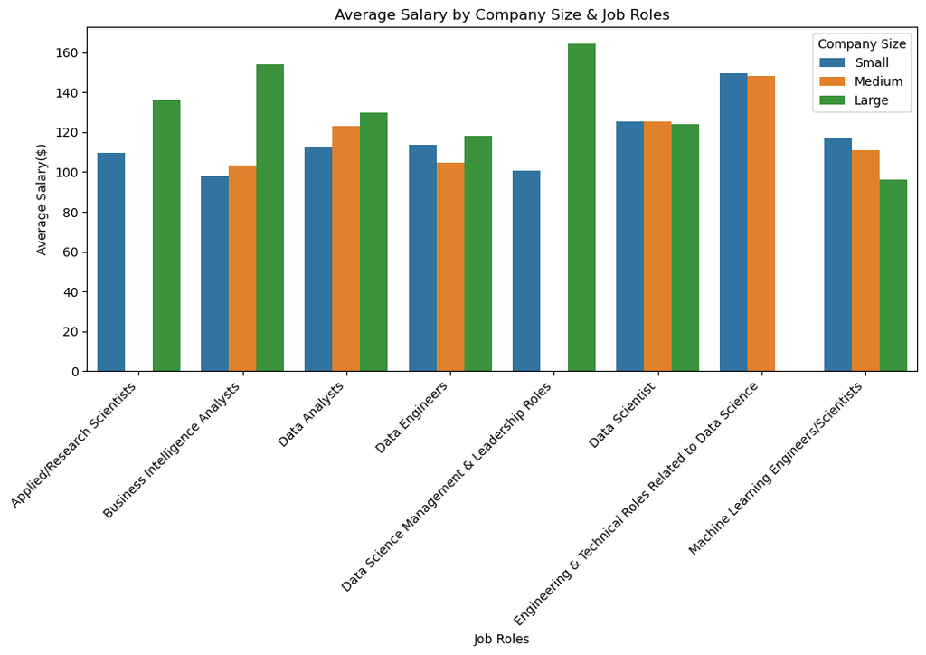

```python
size_order = ['Small', 'Medium', 'Large']
plt.figure(figsize=(12, 5))
sns.barplot(data=df_salary_role, x='role_category', y='Salary Avg', hue='Size Category', hue_order=size_order)

plt.xticks(rotation=45, ha='right')
plt.legend(title='Company Size')

plt.xlabel('Job Roles')
plt.ylabel('Average Salary($)')
plt.title('Average Salary by Company Size & Job Roles')

plt.show()
```

According to the bar chart, for Data Science Management & Leadership Roles, the average salary is highest in large companies. Additionally, Business Intelligence Analysts hired by large companies also have a higher average salary. Data Scientists and Data Analysts have almost the same average salary.

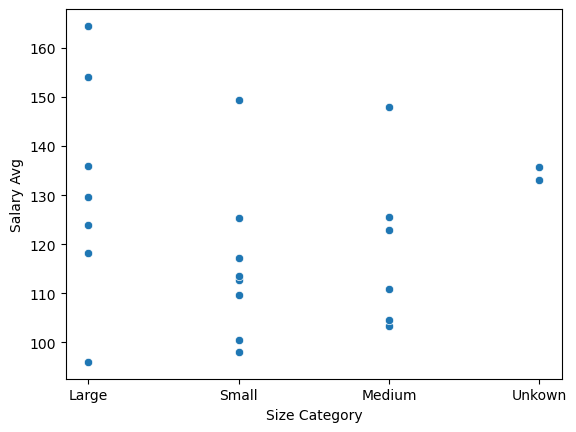

```python
sns.scatterplot(data=df_salary_role, x='Size Category', y='Salary Avg')
plt.show()
```

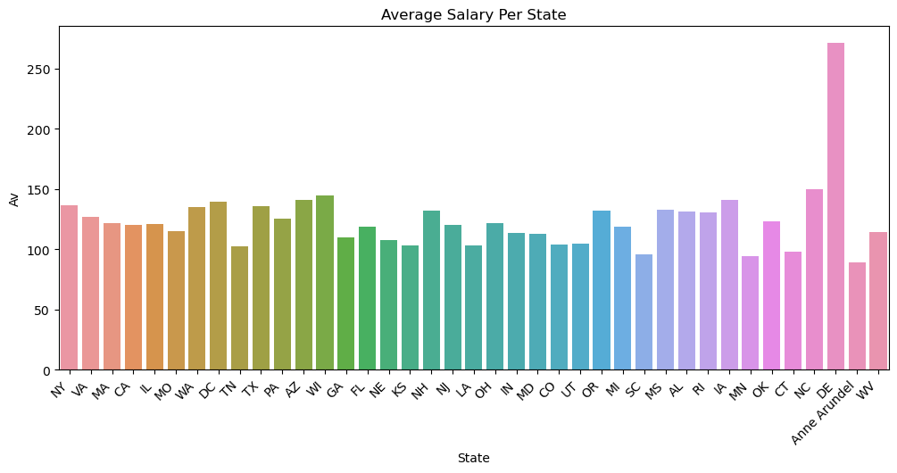

```python
plt.figure(figsize=(12, 5))
sns.barplot(data=df, x='State', y='Salary Avg', errorbar=None)

plt.title('Average Salary Per State')
plt.xlabel('State')
plt.ylabel('Av')

plt.xticks(rotation=45, ha='right')
plt.show()
```

By analyzing the above graph, the state of **DE** has the highest average salary. Let's see which Data Science role contributes to this.

```python
df_filter = df[df['State'] == 'DE']
df_filter
```

|  | index | Job Title | Salary Estimate | Job Description | Rating | Company Name | Location | Headquarters | Size | Founded | ... | Sector | Revenue | Competitors | role_category | Min Salary | Max Salary | Salary Avg | City | State | Size Category |
| --- | --- | --- | --- | --- | --- | --- | --- | --- | --- | --- | --- | --- | --- | --- | --- | --- | --- | --- | --- | --- | --- |
| 509 | 509 | Real World Science, Data Scientist | 212-331 | Title: Real World Science, Data Scientist\nLoc... | 4.0 | AstraZeneca | Wilmington, DE | Cambridge, United Kingdom | 10000+ | 1913 | ... | Biotech & Pharmaceuticals | $10+ billion (USD) | Roche, GlaxoSmithKline, Novartis | Data Scientist | 212 | 331 | 271.5 | Wilmington | DE | Large |

1 rows × 22 columns

Data Scientists hired by large companies in Wilmington, DE, have the highest average salary.

### 2) Which industries are offering the highest-paying data science roles?

```python
indus_role = df.groupby(['Industry', 'role_category'])['Salary Avg'].agg('mean')
df_indus_role = pd.DataFrame(indus_role).reset_index()
df_indus_role.head()
```

|  | Industry | role_category | Salary Avg |
| --- | --- | --- | --- |
| 0 | -1 | Applied/Research Scientists | 148.00000 |
| 1 | -1 | Data Analysts | 103.00000 |
| 2 | -1 | Data Engineers | 133.00000 |
| 3 | -1 | Data Scientist | 129.69403 |
| 4 | -1 | Machine Learning Engineers/Scientists | 133.00000 |

```python
df_indus_role['Industry'] = df_indus_role['Industry'].str.replace('-1','Not Specified')
df_indus_role.head()
```

|  | Industry | role_category | Salary Avg |
| --- | --- | --- | --- |
| 0 | Not Specified | Applied/Research Scientists | 148.00000 |
| 1 | Not Specified | Data Analysts | 103.00000 |
| 2 | Not Specified | Data Engineers | 133.00000 |
| 3 | Not Specified | Data Scientist | 129.69403 |
| 4 | Not Specified | Machine Learning Engineers/Scientists | 133.00000 |

```python
max_10_indus_salary = df_indus_role.groupby('Industry')['Salary Avg'].agg('mean').sort_values(ascending=False).reset_index().head(10)
max_10_indus_salary
```

|  | Industry | Salary Avg |
| --- | --- | --- |
| 0 | Publishing | 271.500000 |
| 1 | Health, Beauty, & Fitness | 203.750000 |
| 2 | Food & Beverage Stores | 183.000000 |
| 3 | Hotels, Motels, & Resorts | 183.000000 |
| 4 | State & Regional Agencies | 183.000000 |
| 5 | Wholesale | 177.000000 |
| 6 | Other Retail Stores | 167.333333 |
| 7 | Architectural & Engineering Services | 154.833333 |
| 8 | Electrical & Electronic Manufacturing | 145.500000 |
| 9 | Transportation Equipment Manufacturing | 140.000000 |

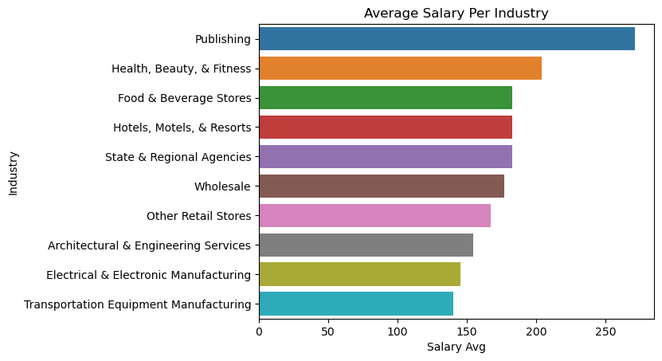

```python
sns.barplot(data=max_10_indus_salary, x='Salary Avg', y='Industry')

plt.title('Average Salary Per Industry')

plt.show()
```

```python
top_indus_list = max_10_indus_salary.index.to_list()
top_hire_indus_role = df_indus_role[df_indus_role['Industry'].isin(top_indus_list)]
top_hire_indus_role
```

|  | Industry | role_category | Salary Avg |
| --- | --- | --- | --- |

### 3) How do company ratings correlate with salary estimates?

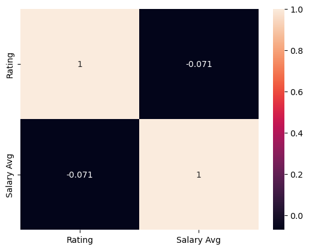

```python
sns.heatmap(data=df[['Rating', 'Salary Avg']].corr(),annot=True )
plt.show()
```

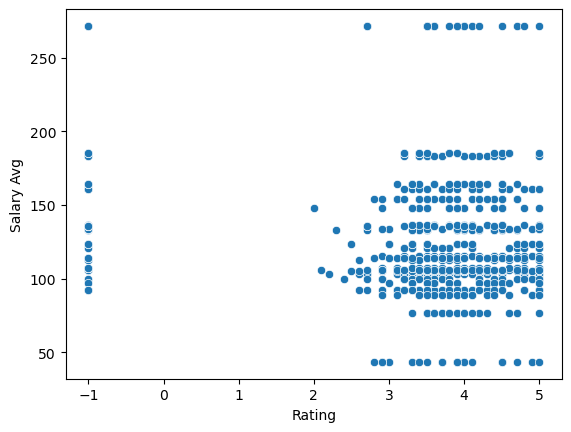

```python
sns.scatterplot(data=df, x='Rating', y='Salary Avg')
plt.show()
```

According to the heatmap and scatterplot, there is no correlation between Rating and Average Salary.

### 4) What skills or keywords appear most frequently in job descriptions?

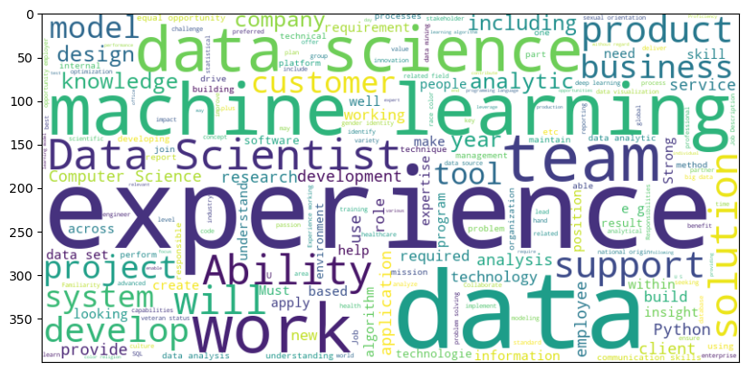

```python
df['Job Description'] = df['Job Description'].fillna('')
df['Job Description'] = df['Job Description'].str.replace('\n', ' ', regex=False)
text = ' '.join(df['Job Description'].astype(str))
wordcloud = WordCloud(width=800, height=400, background_color='white').generate(text)

plt.figure(figsize=(10,5))
plt.imshow(wordcloud, interpolation='bilinear')
plt.xticks([])
plt.show()
```

### 5) Which states and cities have the highest demand for data scientists?

```python
df_location_role = df.groupby(['City', 'State'])['role_category'].agg('count').reset_index().sort_values(by='role_category', ascending=False).head(10)

df_location_role
```

|  | City | State | role_category |
| --- | --- | --- | --- |
| 159 | San Francisco | CA | 69 |
| 117 | New York | NY | 50 |
| 188 | Washington | DC | 26 |
| 19 | Boston | MA | 24 |
| 36 | Chicago | IL | 22 |
| 76 | Herndon | VA | 21 |
| 27 | Cambridge | MA | 18 |
| 104 | McLean | VA | 12 |
| 34 | Chantilly | VA | 11 |
| 164 | Santa Clara | CA | 9 |

The analysis of job demand in the data science sector reveals that San Francisco, CA, leads with the highest number of job postings at 69, reflecting its status as a major tech hub. Following closely is New York, NY, with 50 postings, indicating a strong market for data science professionals. Washington, DC, ranks third with 26 job postings, showcasing the growing need for data scientists in the area. These cities represent the top three locations with the highest demand for data science jobs, emphasizing their significance in the job market.

### 6) How do salaries vary across different company ownership types?

```python
df['Type of ownership'] = df['Type of ownership'].str.replace('-1', 'Unknown')
```

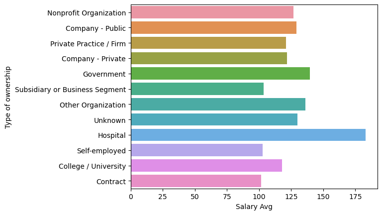

```python
sns.barplot(data=df, x='Salary Avg', y='Type of ownership', errorbar=None)
plt.title('')
plt.show()
```

According to the bar chart, hospitals offer the highest average salary, while other company ownership have nearly the same salary range.

### 7) What are the top industries or sectors hiring for data science roles?

[figure not shown]

```python
df_indus_count = pd.DataFrame(df['Industry'].value_counts()).reset_index().sort_values(by='count',ascending=False).head(6)
df_indus_count = df_indus_count[1:]
sns.barplot(data=df_indus_count, x='count', y='Industry')

plt.xlabel("Number of Employees Hire")
plt.title('Top Industries by Hiring Count')

plt.show()
```

[figure not shown]

```python
df_sector_count = pd.DataFrame(df['Sector'].value_counts()).reset_index().sort_values(by='count',ascending=False).head(6)
df_sector_count = df_sector_count[df_sector_count['Sector'] != '-1']
sns.barplot(data=df_sector_count, x='count', y='Sector')

plt.xlabel("Number of Employees Hire")
plt.title('Top Sectors by Hiring Count')

plt.show()
```

### 8) Which locations have the most data science job openings?

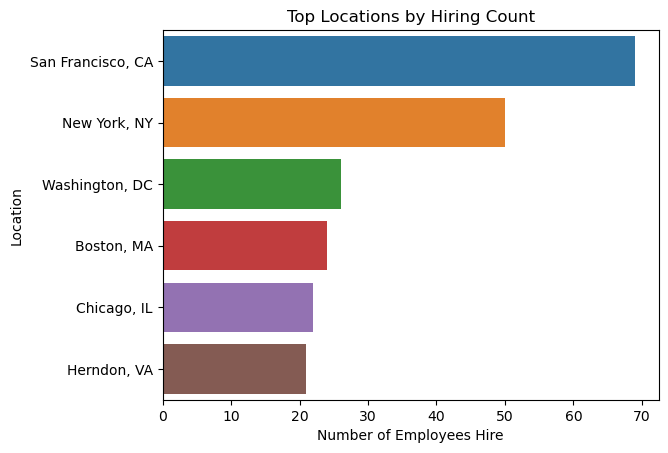

```python
df_loac_count = pd.DataFrame(df['Location'].value_counts()).reset_index().sort_values(by='count',ascending=False).head(6)
df_loac_count = df_loac_count[df_loac_count['Location'] != '-1']
sns.barplot(data=df_loac_count, x='count', y='Location')

plt.xlabel("Number of Employees Hire")
plt.title('Top Locations by Hiring Count')

plt.show()
```

### 9) What is the relationship between a company’s founding years and rating?

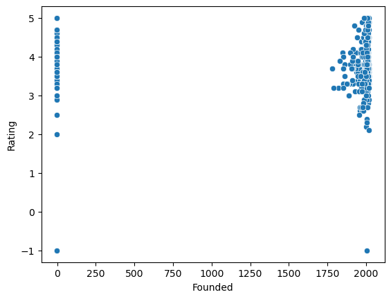

```python
sns.scatterplot(data=df, x='Founded', y='Rating')
plt.show()
```

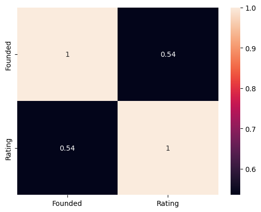

```python
sns.heatmap(data=df[['Founded', 'Rating']].corr(),annot=True )
plt.show()
```

### 10) What are the most common types of ownership among companies posting jobs?

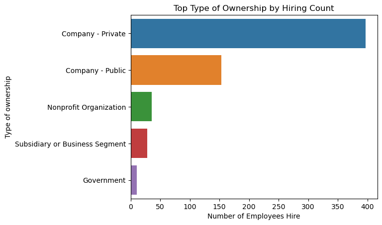

```python
df_own_count = pd.DataFrame(df['Type of ownership'].value_counts()).reset_index().sort_values(by='count',ascending=False).head(6)
df_own_count = df_own_count[df_own_count['Type of ownership'] != 'Unknown']
sns.barplot(data=df_own_count, x='count', y='Type of ownership')

plt.xlabel("Number of Employees Hire")
plt.title('Top Type of Ownership by Hiring Count')

plt.show()
```

Copyright © 2024 Kaung Si Thu - All rights reserved.